# Exploring missing data patterns and mechanisms

Author

Affiliation

Aurélie Bertrand, Laura Symul

Université catholique de Louvain

Published

November 27, 2026

# Introduction

## Dataset

`diabetes` dataset from package `VIM`: a synthetic replacement for the Pima Indians Diabetes data

- **Data about diabetes on females at least 21 years old of Pima Indian heritage**.
- One column removed (DiabetesPedigreeFunction).

```r
library(VIM)
pa_data <- diabetes[-7]
levels(pa_data$Outcome) <- c("No diabetes", "Diabetes")
```

## Useful packages for documenting missing data

- Base `R` functions
- Tools from the `tidyverse` suite
- Dedicated packages, among which:
  - `naniar` (see https://naniar.njtierney.com/)
  - `VIM`

```r
pacman::p_load(c(naniar, VIM))
```

# Data overview

## Textual output

```r
str(pa_data)
```

```
'data.frame':   768 obs. of  8 variables:
 $ Pregnancies  : int  0 8 2 6 4 10 3 1 4 7 ...
 $ Glucose      : int  194 129 132 184 108 117 100 88 73 126 ...
 $ BloodPressure: int  50 84 72 62 58 80 80 75 82 92 ...
 $ SkinThickness: int  45 NA 42 NA 32 13 41 30 38 NA ...
 $ Insulin      : int  NA NA NA NA NA NA 65 49 NA NA ...
 $ BMI          : num  28.5 27.6 38.2 24.7 31.6 30.1 46.3 32.4 44.2 37.3 ...
 $ Age          : int  28 44 26 39 22 58 33 22 33 46 ...
 $ Outcome      : Factor w/ 2 levels "No diabetes",..: 1 2 1 1 1 2 2 1 1 2 ...
```

## Tabular output

```r
skimr::skim(pa_data)
```

Data summary

| Name | pa_data |
| --- | --- |
| Number of rows | 768 |
| Number of columns | 8 |
| _______________________ |  |
| Column type frequency: |  |
| factor | 1 |
| numeric | 7 |
| ________________________ |  |
| Group variables | None |

**Variable type: factor**

| skim_variable | n_missing | complete_rate | ordered | n_unique | top_counts |
| --- | --- | --- | --- | --- | --- |
| Outcome | 0 | 1 | FALSE | 2 | No : 488, Dia: 280 |

**Variable type: numeric**

| skim_variable | n_missing | complete_rate | mean | sd | p0 | p25 | p50 | p75 | p100 | hist |
| --- | --- | --- | --- | --- | --- | --- | --- | --- | --- | --- |
| Pregnancies | 0 | 1.00 | 4.58 | 3.88 | 0.0 | 1.0 | 3.0 | 7.00 | 13.0 | ▇▆▃▂▂ |
| Glucose | 5 | 0.99 | 125.30 | 31.59 | 57.0 | 101.0 | 119.0 | 144.50 | 199.0 | ▁▇▆▃▂ |
| BloodPressure | 35 | 0.95 | 72.59 | 12.19 | 24.0 | 64.0 | 72.0 | 80.00 | 108.0 | ▁▁▇▆▁ |
| SkinThickness | 251 | 0.67 | 29.46 | 9.96 | 7.0 | 22.0 | 30.0 | 36.00 | 63.0 | ▃▇▇▃▁ |
| Insulin | 405 | 0.47 | 159.05 | 123.34 | 14.0 | 76.0 | 125.0 | 194.00 | 846.0 | ▇▂▁▁▁ |
| BMI | 13 | 0.98 | 32.87 | 7.02 | 18.2 | 27.8 | 32.8 | 36.95 | 59.4 | ▃▇▅▁▁ |
| Age | 0 | 1.00 | 33.05 | 11.94 | 21.0 | 24.0 | 28.0 | 41.00 | 81.0 | ▇▂▁▁▁ |

## Graphical output

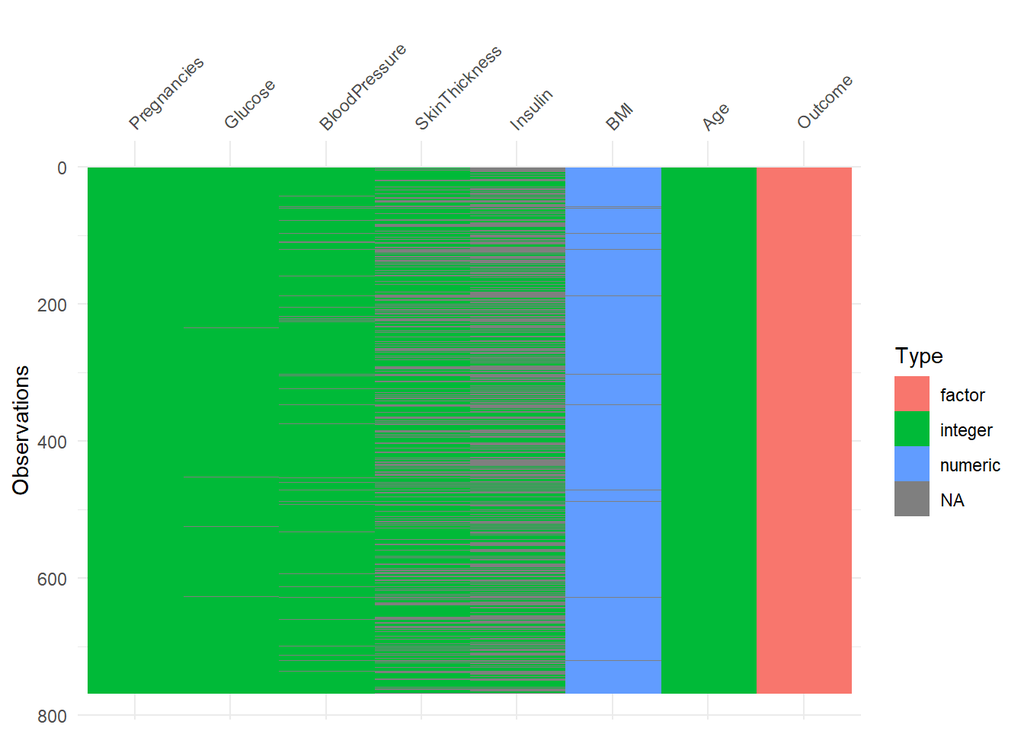

```r
visdat::vis_dat(pa_data, sort_type = FALSE) +
  theme(axis.text.x.top = element_text(vjust = 0))
```

# Documenting missing data

Visualization above: a good glimpse of the data.

Here: more specific summary statistics and visualizations to **explore the patterns and mechanisms of missing data**.

## Overview of missingness

### Data overview

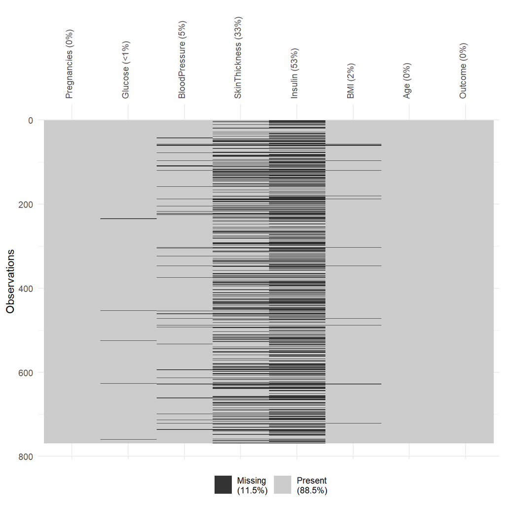

```r
visdat::vis_miss(pa_data) + # naniar::vis_miss(pa_data) # equivalent
  theme(axis.text.x.top = element_text(angle = 90, vjust = 0))
```

- For reasonably small datasets: very informative.
- For larger datasets: may not fit on the screen and be less useful $\Rightarrow$ need **summaries**.

### Missingness by variable

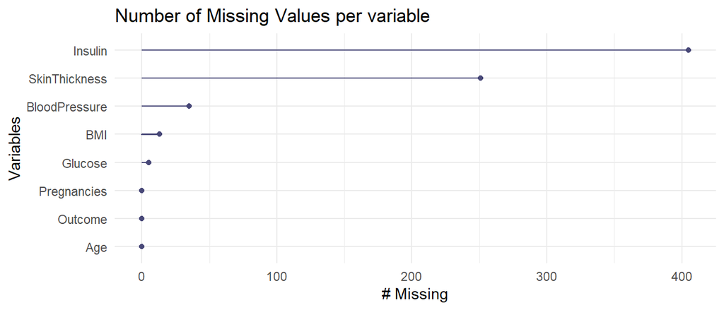

```r
naniar::gg_miss_var(pa_data) +
  ggtitle("Number of Missing Values per variable")
```

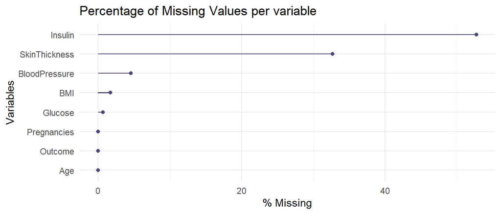

```r
naniar::gg_miss_var(pa_data, show_pct = TRUE) +
  ggtitle("Percentage of Missing Values per variable")
```

### Missingness by case

```r
naniar::miss_case_table(pa_data) |>
  gt::gt() |>
  gt::cols_label(
    n_miss_in_case ~ "# missing variable in case",
    n_cases = "N cases",
    pct_cases = "% cases"
  )
```

| # missing variable in case | N cases | % cases |
| --- | --- | --- |
| 0 | 362 | 47.135417 |
| 1 | 147 | 19.140625 |
| 2 | 227 | 29.557292 |
| 3 | 20 | 2.604167 |
| 4 | 12 | 1.562500 |

## Co-missingness (missingness patterns)

Investigate if some variables are systematically or more frequently missing in the same cases.

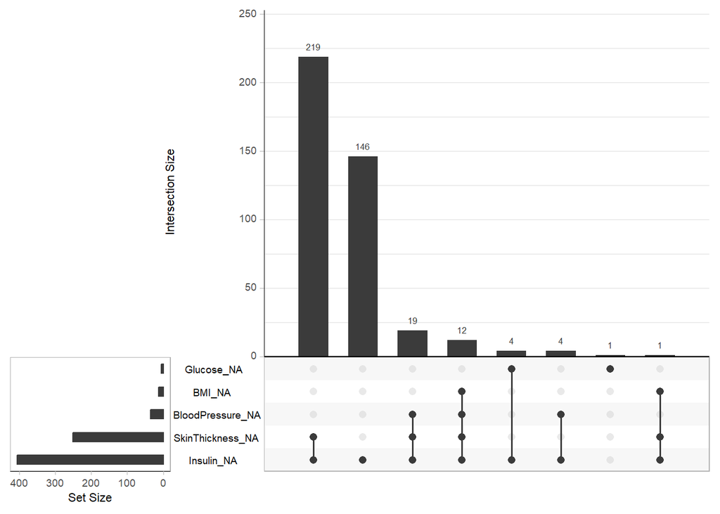

```r
naniar::gg_miss_upset(pa_data)
```

Insulin and Skin Thickness very often missing at the same time.

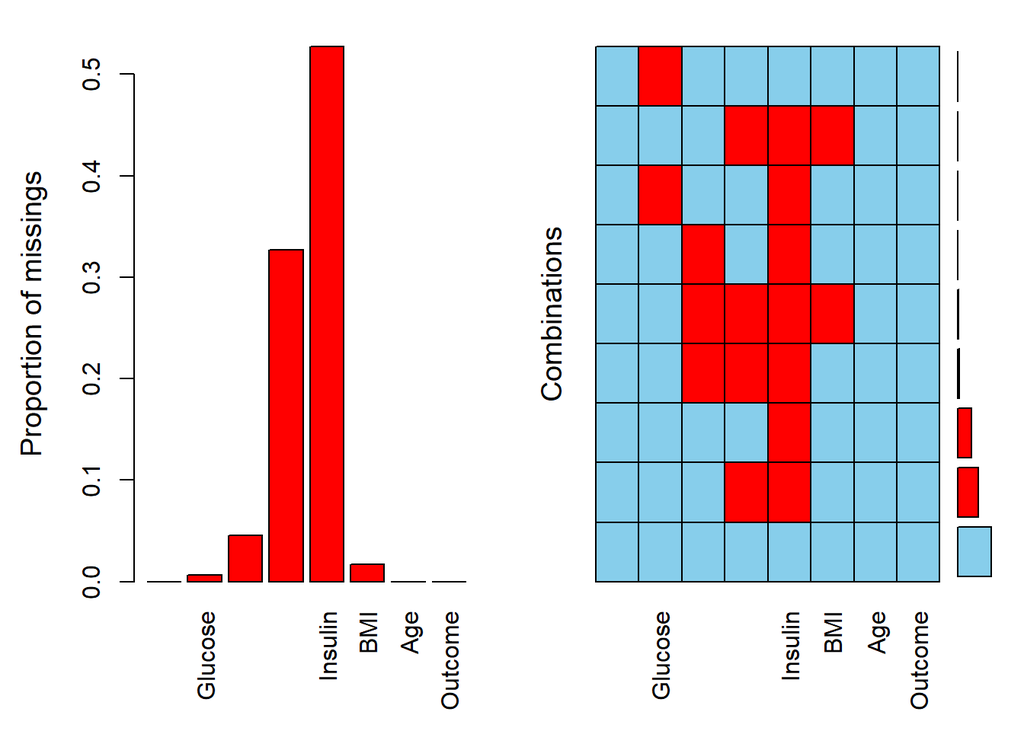

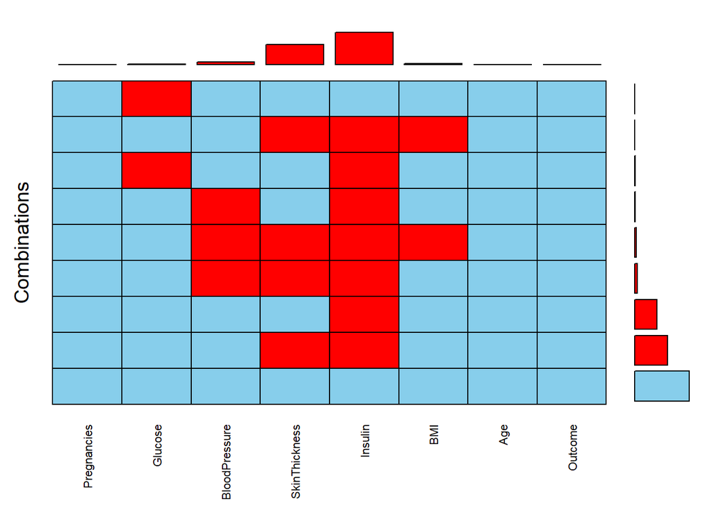

```r
plot(VIM::aggr(pa_data), combined = TRUE, cex.axis = 0.7)
```

## Link between missingness and other variables

### Overview of missingness by category of a factor

- Visualize the **missing status of each cell for each diabetes status**.
- To check whether the proportion of missing values in a variable seems to be associated with the diabetes status.

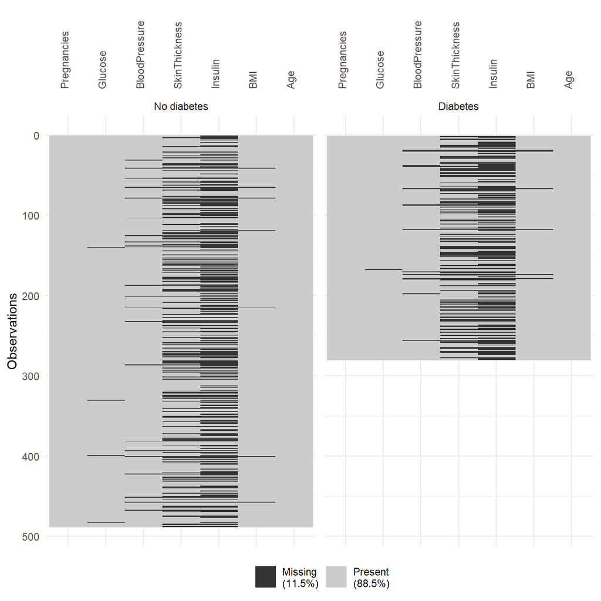

```r
naniar::vis_miss(pa_data, facet = Outcome) +
  theme(axis.text.x.top = element_text(angle = 90, vjust = 0))
```

- No obvious link between diabetes status and proportion of missingness in other variables.

### Data overview by sorting on a variable

- Visualization of the whole dataset (missing values and observed values).
- By sorting the rows by one variable, we can investigate **whether the missingness in the other variables seems to be associated with this variable**.

Rows sorted by Age.

*Beware: here,*

- *black cells are observed values*
- *red cells are missing values*

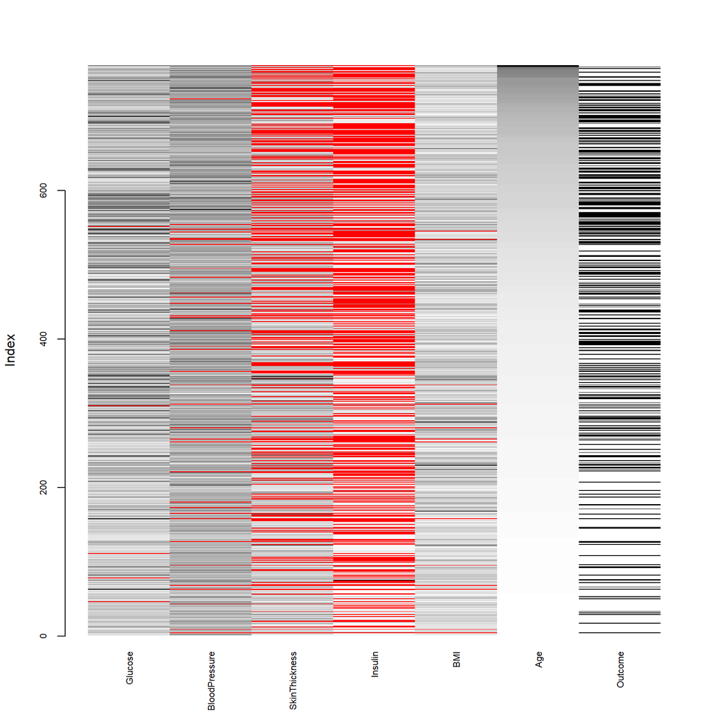

```r
VIM::matrixplot(pa_data[,-1], sortby = "Age", cex.axis = 0.7)
```

- Missing values in Blood Pressure and BMI seem more frequent for young people.

Rows sorted by Glucose.

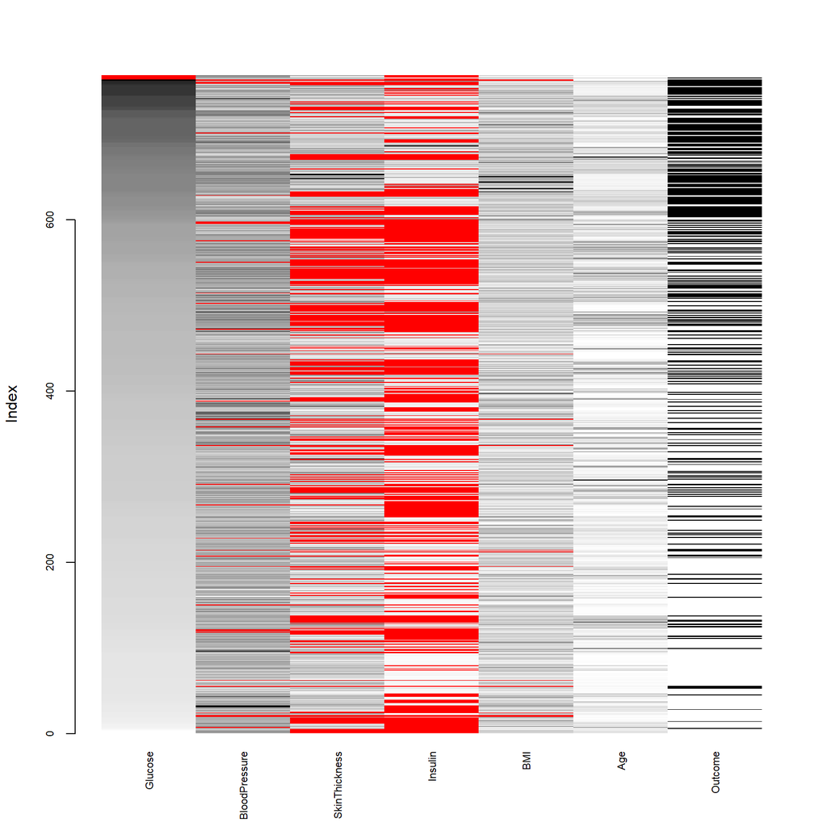

```r
VIM::matrixplot(pa_data[,-1], sortby = "Glucose", cex.axis = 0.7)
```

- No obvious trend between Glucose level and missingness in other variables.

Rows sorted by diabetes status.

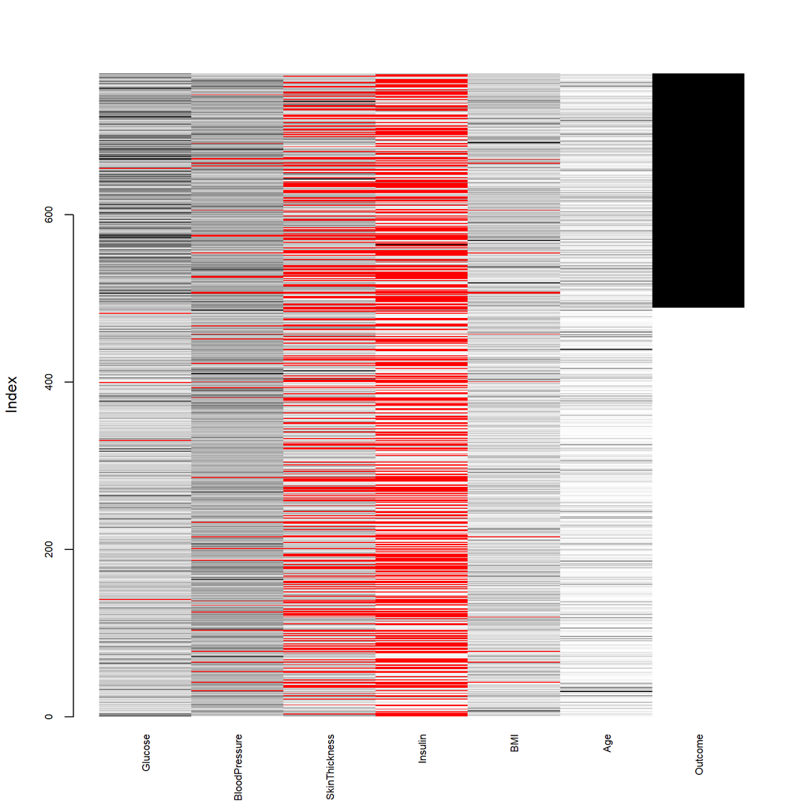

```r
VIM::matrixplot(pa_data[,-1], sortby = "Outcome", cex.axis = 0.7)
```

### Bivariate tools

#### Classical tools

**Proportion of missing Insulin for each diabetes status**

```r
round(prop.table(table(pa_data$Outcome, is.na(pa_data$Insulin)), margin = 1),2)
```

```
              FALSE TRUE
  No diabetes  0.50 0.50
  Diabetes     0.43 0.57
```

- Missingness in Insulin seems more frequent for patients with diabetes than for patients without diabetes.

**Distribution of Pregnancies for patients with missing Insulin vs. patients with observed Insulin values**

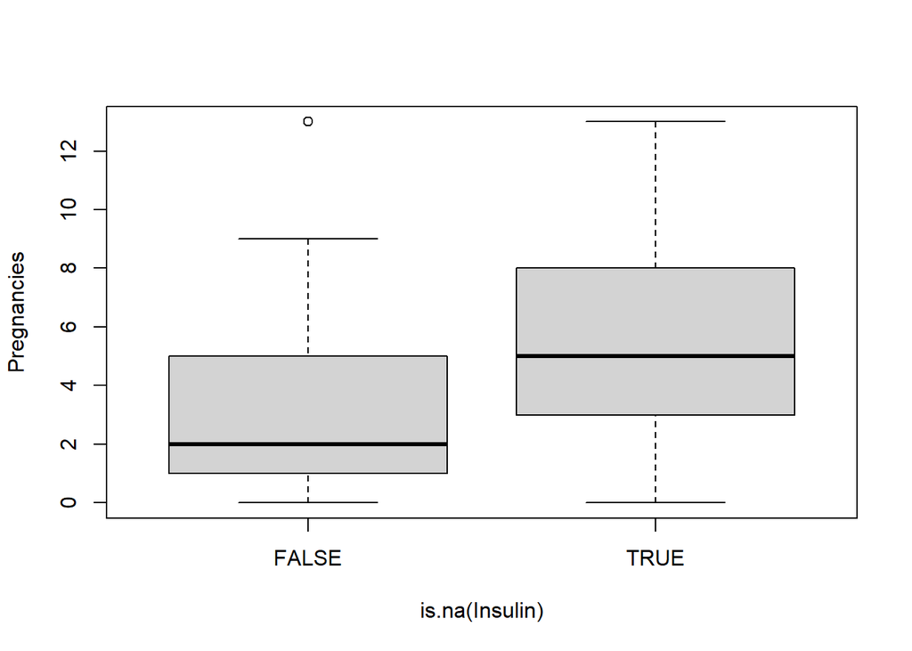

```r
boxplot(Pregnancies ~ is.na(Insulin), data = pa_data)
```

- Patients with missing Insulin values tend to have more pregnancies than patients with observed Insulin values.

#### Tools dedicated to missing values

Visualize:

- the relationship between two variables (will be useful for multiple imputation).
- the relationship between the missingness in one of them and the observed values of the other one.

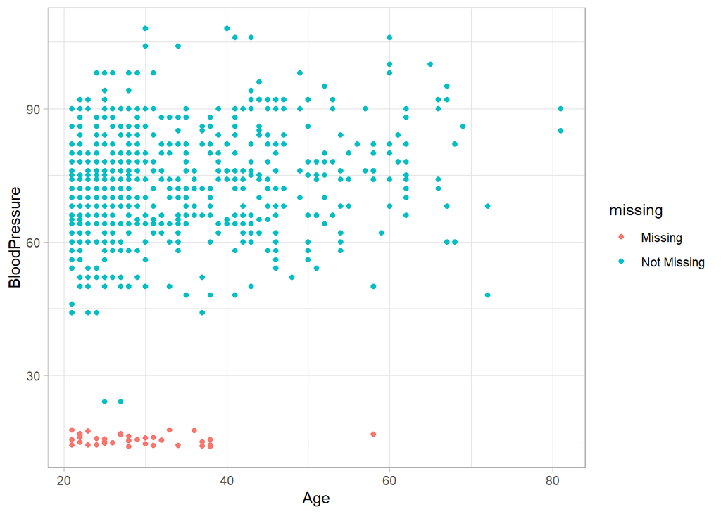

```r
pa_data |>
  ggplot() +
  aes(x = Age, y = BloodPressure) +
  naniar::geom_miss_point(alpha = 1)
```

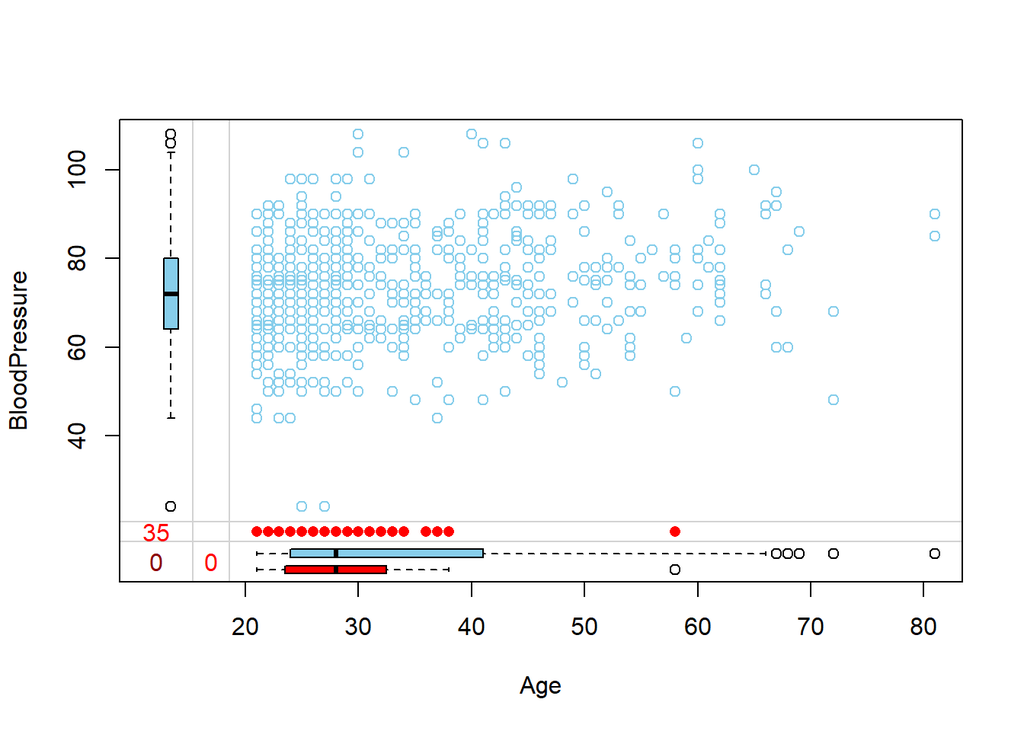

```r
VIM::marginplot(pa_data[c("Age","BloodPressure")], cex.axis = 1)
```

- Link between Age and missingness in Blood Pressure: missing values in Blood Pressure are more frequent for young people.
- Dispersion of Age is larger for cases with no missing value in BloodPressure.

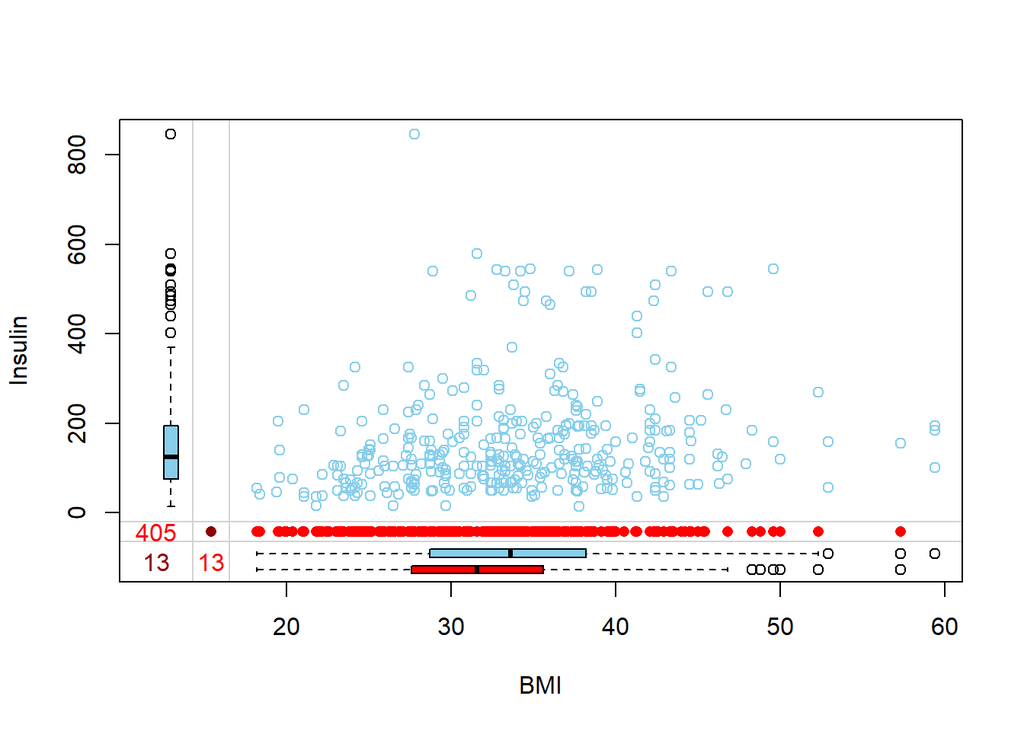

```r
VIM::marginplot(pa_data[c("BMI","Insulin")], cex.axis = 1)
```

- Patients with missing values in Insulin tend to have a lower BMI than patients with observed values in Insulin.